# Final Homework

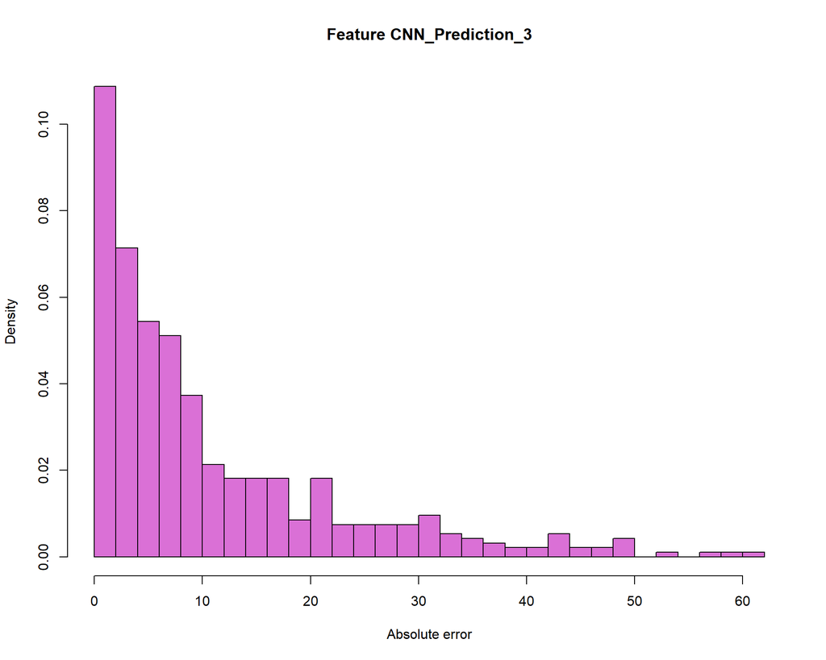

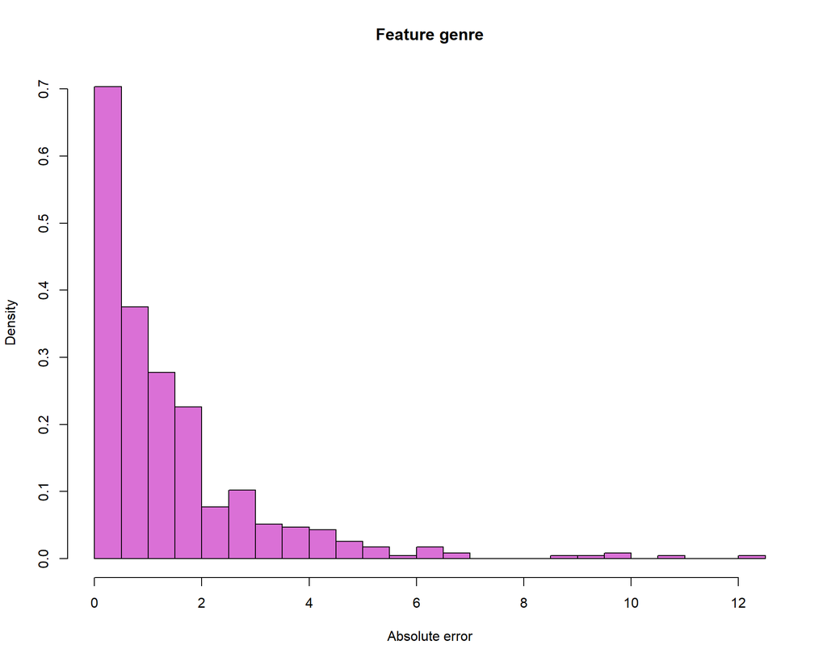

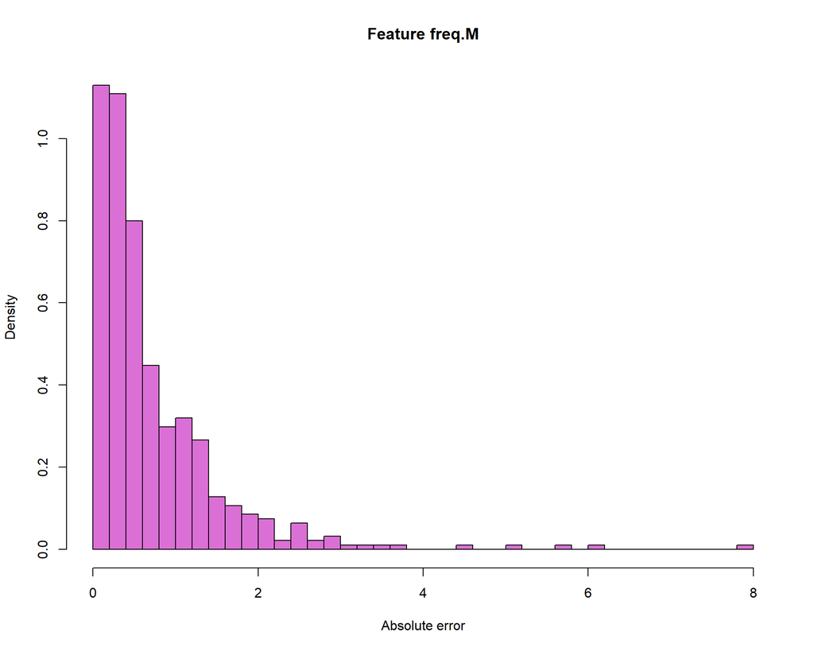

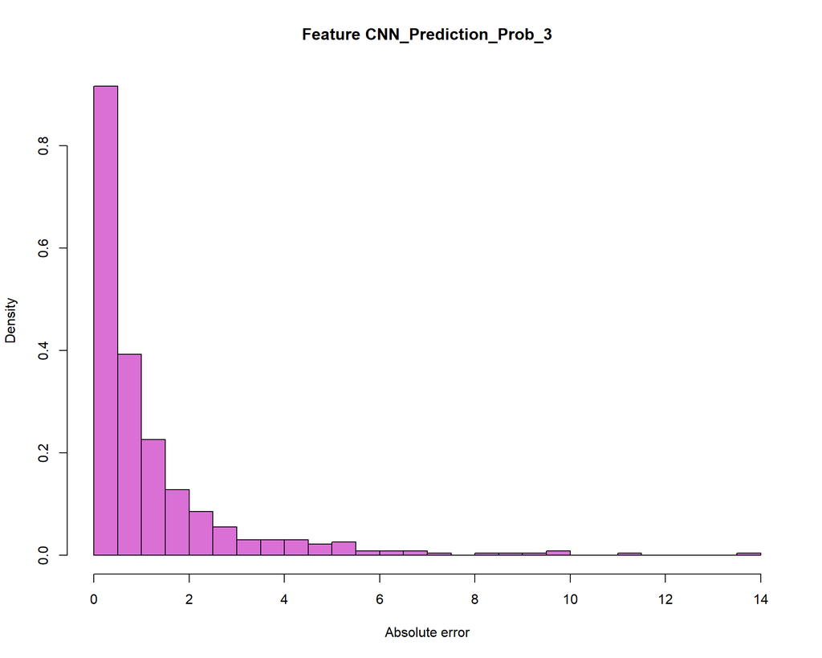

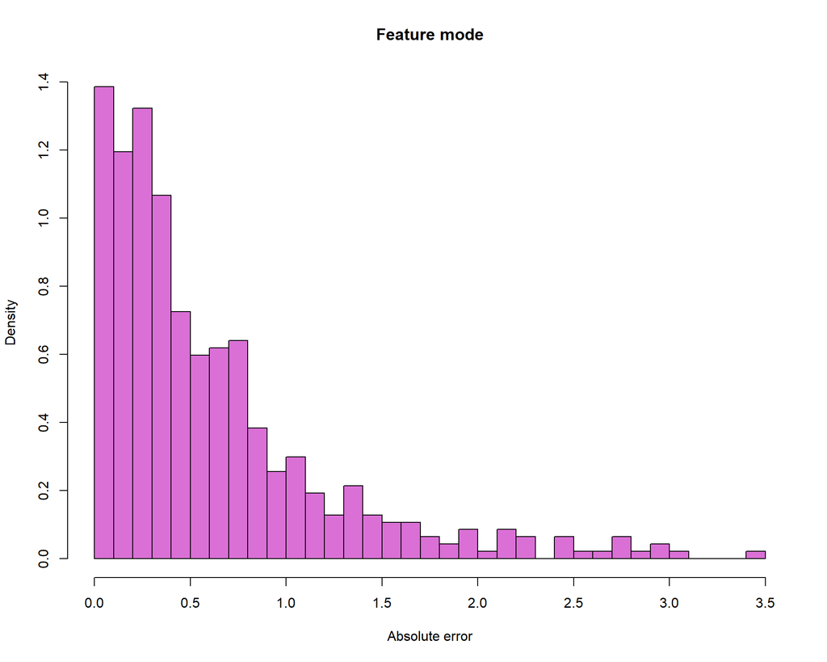

We will also plot the distribution of the median of the prediction error. We can observe that the average value of this median is very close to the true median value (LLN). It can also be appreciated that the distribution of this median is Gaussian, which justifies the choice made to compute the confidence intervals for this quantity.

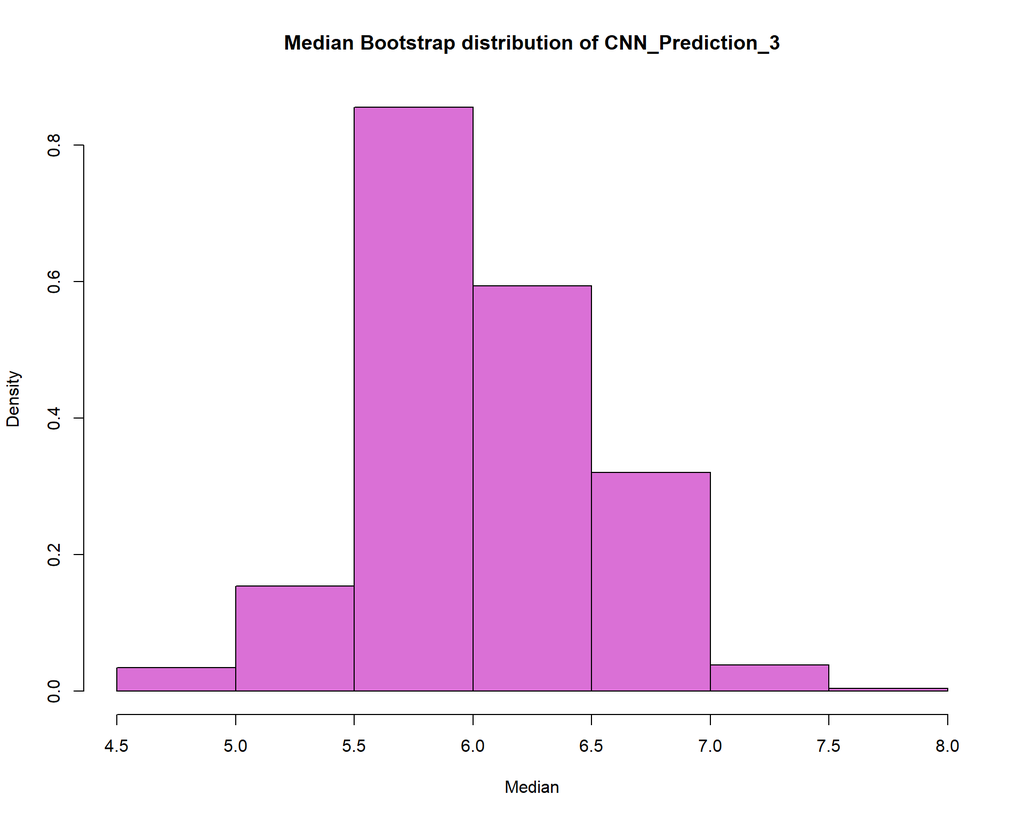

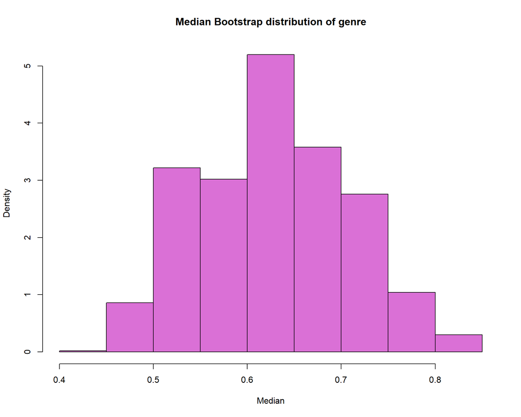

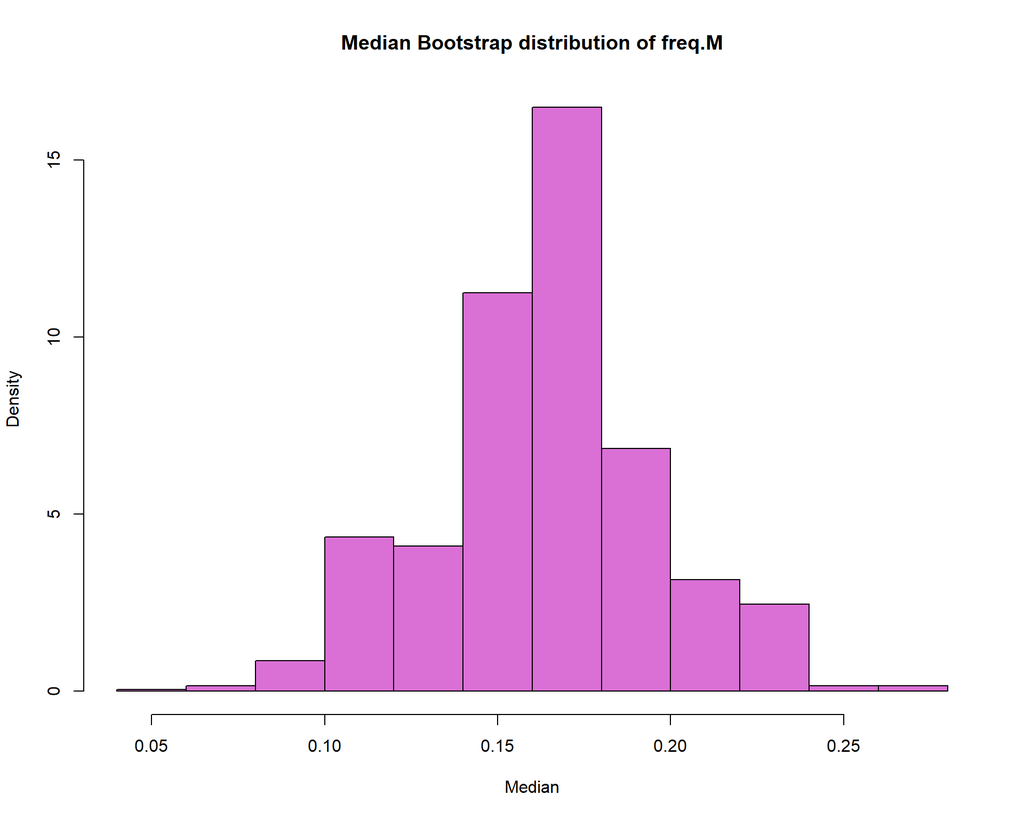

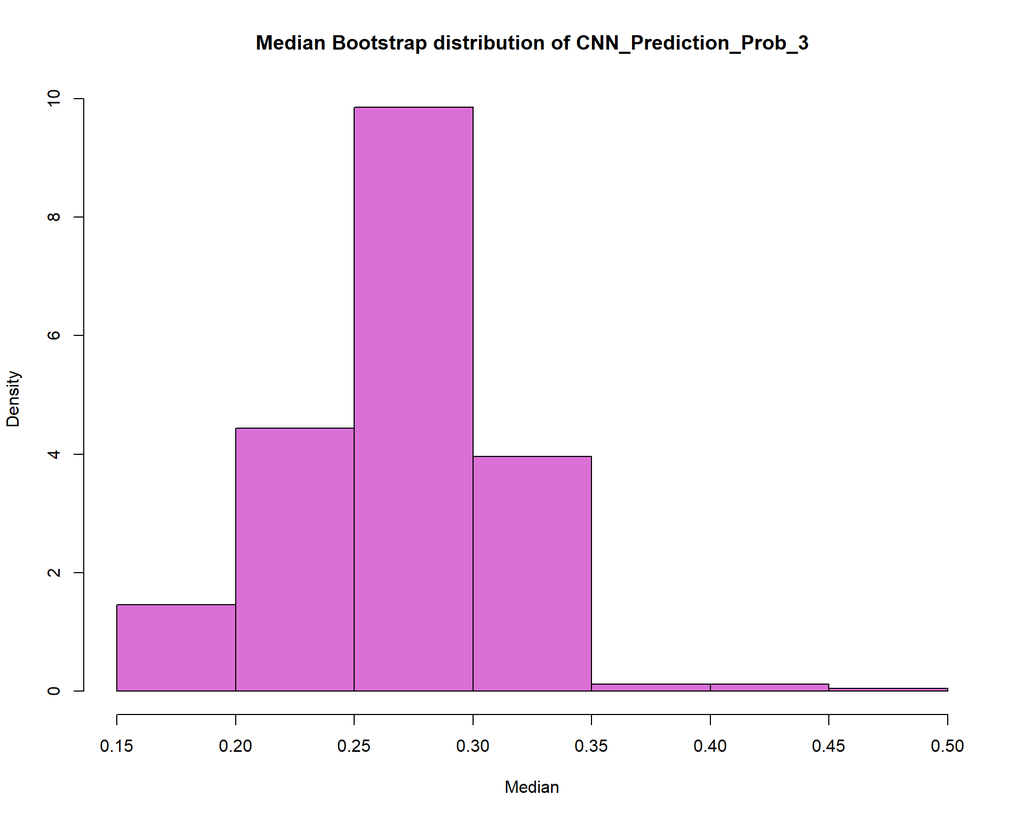

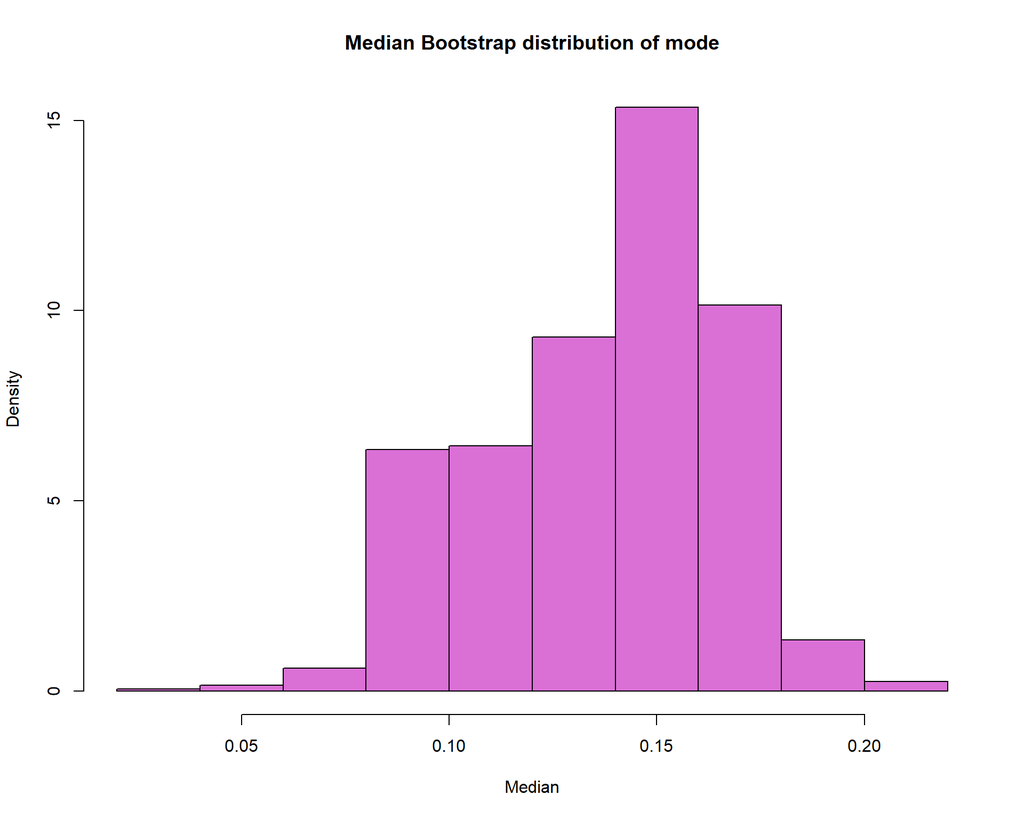

Finally, another representation of how much more impact the feature CNN_Prediction_3 has over the other variables is the following plot, in which we have also included the confidence interval around the true median value.

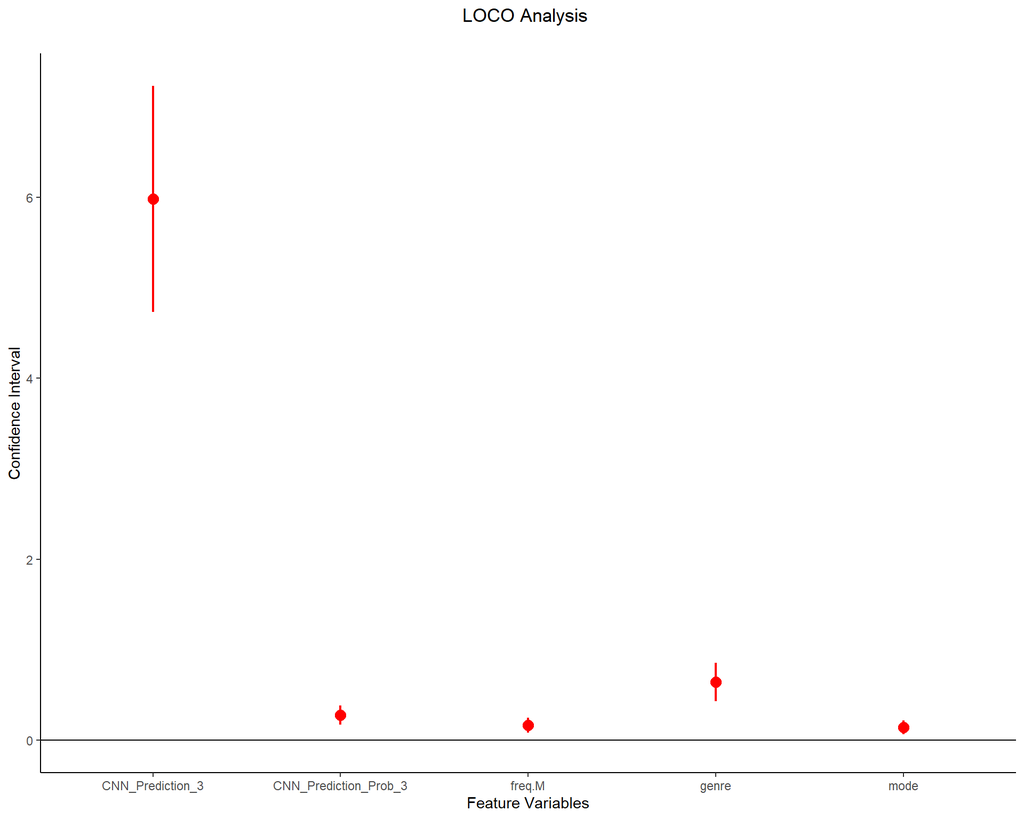

In conclusion, we can say that the variable that has most impact on the prediction error is CNN_Prediction_3, which is in line with our initial expectation. The random forest is able to identify that this variable already acts as a very good predictor and simply tries to correct it (mainly using the other top 4 feature variables).